# Parameter Estimation - Wild Fish Catch

Vanessa Rathbone

3/5/2021

Nonlinear least squares (NLS) finds parameter estimates to minimize the sum of squares of residuals, using an iterative algorithm. We’ll use NLS to find the parameters for a logistic growth equation.

**Data Source:** Global wild fish catch and aquaculture production, compiled by Earth Policy Institute with 1950-2010 from U.N. Food and Agriculture Organization (FAO), Global Capture Production and Global Aquaculture Production, electronic databases

## Read in the data and visualize it

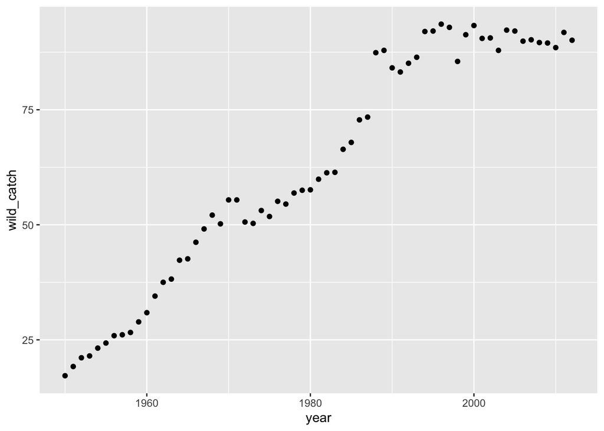

There is a linear relationship between wild fish caught over time. Around the 1990s, however, you can see some type of plateau, either a threshold of fish being caught due to abundance (or carrying capacity), or a limit to how many fish can be caught due to permitting. This can be described mathematically by the following logistic growth equation:

$P(t)=\frac{K}{1+Ae^{-kt}}$, where

- $K$ is the carrying capacity
- $A$ is $\frac{K-P_0}{P_0}$
- $P_0$ is the population at time zero
- $P(t)$ is the population at time $t$
- $k$ is the growth rate constant

Initial estimates for the parameters in the model are:

- $K$ is ~ 90
- $A$ is ~ 5
- $k$ is ~ 0.04

## Non-Linear Least Squares Calculation

**Table 1.** Non-Linear Least Squares for Wild Fish Caught (million tons) 1950-2016.

| Non-Linear Least Squares for Wild Fish Caught (million tons) 1950-2016 Variable | Non-Linear Least Squares for Wild Fish Caught (million tons) 1950-2016 Estimated Value | Non-Linear Least Squares for Wild Fish Caught (million tons) 1950-2016 Standard Error | Non-Linear Least Squares for Wild Fish Caught (million tons) 1950-2016 Statistic | Non-Linear Least Squares for Wild Fish Caught (million tons) 1950-2016 P-value |
| --- | --- | --- | --- | --- |
| K | 100 | 2.73 | 36.7 | 8.57e-43 |
| A | 4.32 | 0.293 | 14.7 | 1.34e-21 |
| r | 0.0699 | 0.00465 | 15 | 5.14e-22 |

## Finalized visualization of observed vs. predicted values

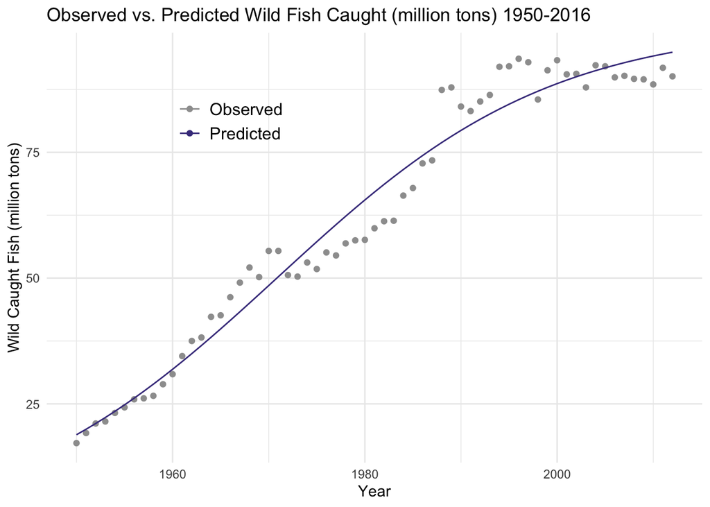